# Differential Expression Analysis

[figure not shown]

# Forewords

In this presentation, there will be screen captures, for you to follow the lesson. There will also be R command lines (hidden by default). Do not take care of the command lines if you find them too challenging. Our goal here, is to understand the main mechanism of Differential Expression Analysis. R is just a tool.

```r
library(package = "knitr")
library(package = "dplyr")
library(package = "singleCellTK")
library(package = "Seurat")
library(package = "ggplot2")
library(package = "ggpubr")
library(package = "rstatix")
```

## Load RDS dataset

```r
integrated_sctk <- readRDS(file = "dataset/INTEGRATED_02d_ClustLab.rds")
```

In SingleCellTK, click “Data”.

1. Import SingleCellExperiment or Seurat object stored in an RDS file
2. click “Browse” and select INTEGRATED_02d_ClustLab.rds
3. click “Add To Sample List”
4. click “Import”
5. wait …
6. Set “Rownames (Default)” as “Feature for Display”

This may be a bit long, depending on the size of the input dataset.

## Insight

Have a look at your dataset. The Shiny interface returns the following description:

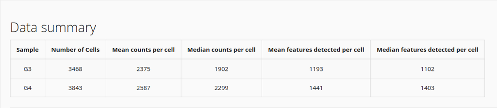

Aside, we might want to look at this dataset through R, using the function [`head`](https://www.rdocumentation.org/packages/utils/versions/3.6.2/topics/head).

```r
head(integrated_sctk)
```

```
class: SingleCellExperiment
dim: 6 7311
metadata(8): assayType sctk ... batchCorr misc
assays(2): counts SLNst
rownames(6): Mrpl15 Lypla1 ... Rb1cc1 Pcmtd1
rowData names(4): rownames counts_filter
  seurat_variableFeatures_vst_varianceStandardized
  seurat_variableFeatures_vst_mean
colnames(7311): G3.1 G3.2 ... G4.4586 G4.4587
colData names(27): sample nCount ... SingleR_immgen_fine_delta.next
  SingleR_immgen_fine_pruned.labels
reducedDimNames(5): QC_UMAP SLNst2K_seuratPCA
  SLNst2K_seuratPCA_seuratUMAP20 PCA_FMNN PCA_FMNN_seuratUMAP30
mainExpName: NULL
altExpNames(1): SLNst2K
```

We can see the name of the normalized dataset and raw counts, we read the name of the dimension reduction steps, we can see the number of cells (7311) and the list of available metadata (8). This information is quite precious when you recieve an unknown dataset, but here, we know where these data come from.

# Hands on a single gene

Question is now to guess wether a gene is differnetially expressed or not.

## Case of the gene Jund

Let’s have a look at the gene named [‘Jund’](https://www.genecards.org/cgi-bin/carddisp.pl?gene=jund), involved in senescence and apoptosis.

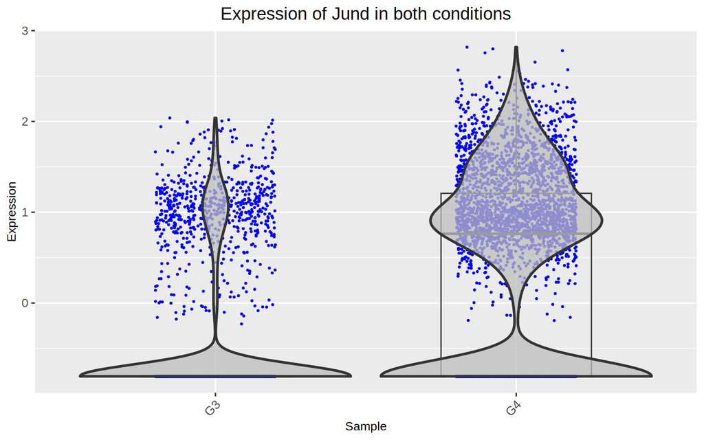

```r
singleCellTK::plotSCEViolin(
  inSCE=integrated_sctk,
  feature="Jund",
  slotName="assays",
  itemName="SLNst",
  groupBy="sample",
  ylab="Expression",
  xlab="Sample",
  defaultTheme=FALSE,
  title="Expression of Jund in both conditions"
)
```

Using ‘intuition’, is that gene differentially expressed ?

I can give you expression density for that gene if it helps:

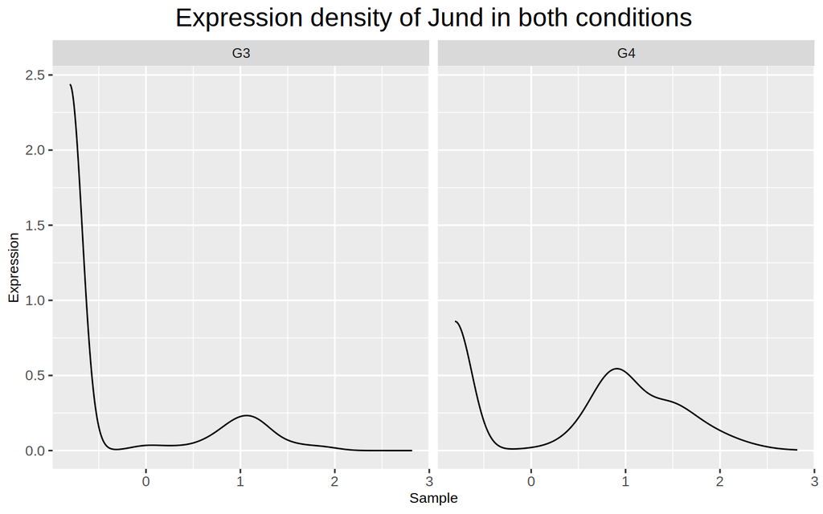

```r
singleCellTK::plotSCEDensity(
  inSCE=integrated_sctk,
  feature="Jund",
  slotName="assays",
  itemName="SLNst",
  groupBy="sample",
  ylab="Expression",
  xlab="Sample",
  defaultTheme=FALSE,
  title="Expression density of Jund in both conditions"
)
```

Okay, let’s have some informations about these distributions.

Within the G3 group:

```r
countsG3 <- as.data.frame(
  SummarizedExperiment::assay(x=integrated_sctk, i="SLNst")
) %>% select( matches("^G3."))

JundG3 <- as.data.frame(t(countsG3["Jund", ]))
JundG3$Group <- "G3"

summary(JundG3)
```

```
      Jund            Group
 Min.   :-0.8072   Length:3468
 1st Qu.:-0.8072   Class :character
 Median :-0.8072   Mode  :character
 Mean   :-0.4501
 3rd Qu.:-0.8072
 Max.   : 2.0387
```

Withing the G4 group:

```r
countsG4 <- as.data.frame(
  SummarizedExperiment::assay(x=integrated_sctk, i="SLNst")
) %>% select( matches("^G4."))

JundG4 <- as.data.frame(t(countsG4["Jund", ]))
JundG4$Group <- "G4"

summary(JundG4)
```

```
      Jund            Group
 Min.   :-0.8072   Length:3843
 1st Qu.:-0.8072   Class :character
 Median : 0.7629   Mode  :character
 Mean   : 0.4061
 3rd Qu.: 1.2086
 Max.   : 2.8188
```

## From biology to statistics

Okay, let us resort on statistics to evaluate our chances to be guess correctly.

We have lots of observations: 3 468 cells in G3 group, and 3 843 cells in G4 groups. Statisticians really like to have a lot of observations! Ideally, statisticians always want to have more observation than tests. We have a total of 7311 observations and we are testing 1 gene. For them, this is a dream come true!

Our cells are supposed to be interactig with each others ? Are they independent from each others ? This is very important, and usually, it requires a discussion.

Does the expression in our cells follow a normal distribution ? It’s easy to check. Let’s draw the expression like we did above:

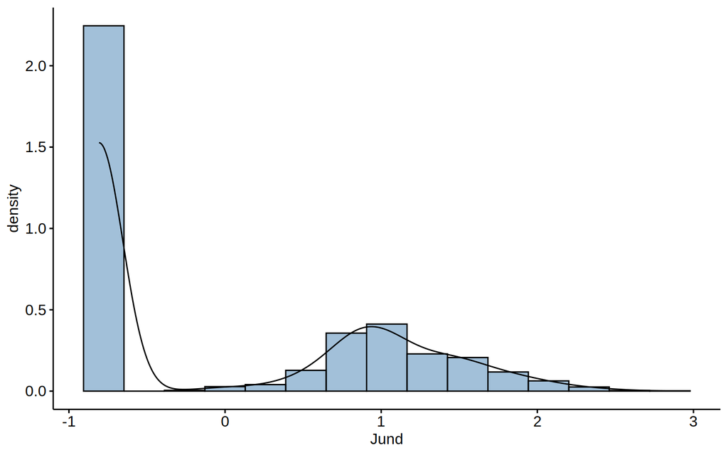

```r
Jund <- rbind(JundG3, JundG4)
gghistogram(Jund, x="Jund", y = "..density..", fill = "steelblue", bins=15, add_density=TRUE)
```

Our distribution seems to be binomial we will have to rely on non-parametric tests.

Let’s run a non-parametric test base on the mean of distributions, since it’s the clothest to our ‘intuitive’ approach. Let there be [Wilcoxon](https://en.wikipedia.org/wiki/Wilcoxon_signed-rank_test) test.

```r
stat.test <- Jund %>% wilcox_test(Jund ~ Group) %>% add_significance()
eff.size <- Jund %>% wilcox_effsize(Jund ~ Group)
```

Wilcoxon test result

| .y. | group1 | group2 | n1 | n2 | statistic | p | p.signif |
| --- | --- | --- | --- | --- | --- | --- | --- |
| Jund | G3 | G4 | 3468 | 3843 | 3766722 | 0 | **** |

```r
singleCellTK::plotSCEViolin(
  inSCE=integrated_sctk,
  feature="Jund",
  slotName="assays",
  itemName="SLNst",
  groupBy="sample",
  ylab="Expression",
  xlab="Sample",
  defaultTheme=FALSE,
  title="Expression of Jund in both conditions"
) + stat_pvalue_manual(
  stat.test, tip.length = 0
) + labs(
  subtitle = get_test_label(stat.test, detailed = TRUE)
)
```

[output not shown]